# Cellranger mkfastq (BCL to FASTQ conversion)

hongc2@ccf.org

1/16/2020

### BCL to FASTQ conversion

- Sample sheet

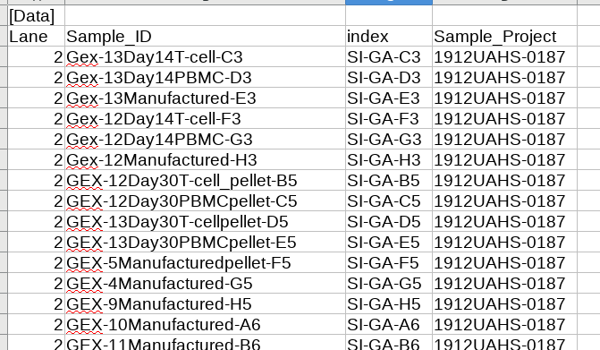

  Fig1. A sample worksheet used in sequencing in 10x Genomics Chromium platform

- We need to convert the Illumina sequencer’s base call (BCL) files to a FASTQ file format. 10x Genomics provides software called cellranger. For instance, we can run

  ```markdown
  cellranger mkfastq --id=${run_id} --run=${bcl_folder} --csv=${sample_worksheet_used_in_sequencing}
  ```

- The output generates 3 folders that include the FASTQ file folder, Reports, and Stats folders.
- Refer to [cellranger.mkfastq](https://support.10xgenomics.com/single-cell-gene-expression/software/pipelines/latest/using/mkfastq) to explore the program option in more details.
- Demultiplexing: In general, more than one sample is loaded into multiple flowcells and the conversion process recognizes sample barcodes and groups them into the same sample.
- What is a FASTQ file like? After mkfastq run, sample folders defined in the input sample sheet are created and each sample folder has FASTQ files.

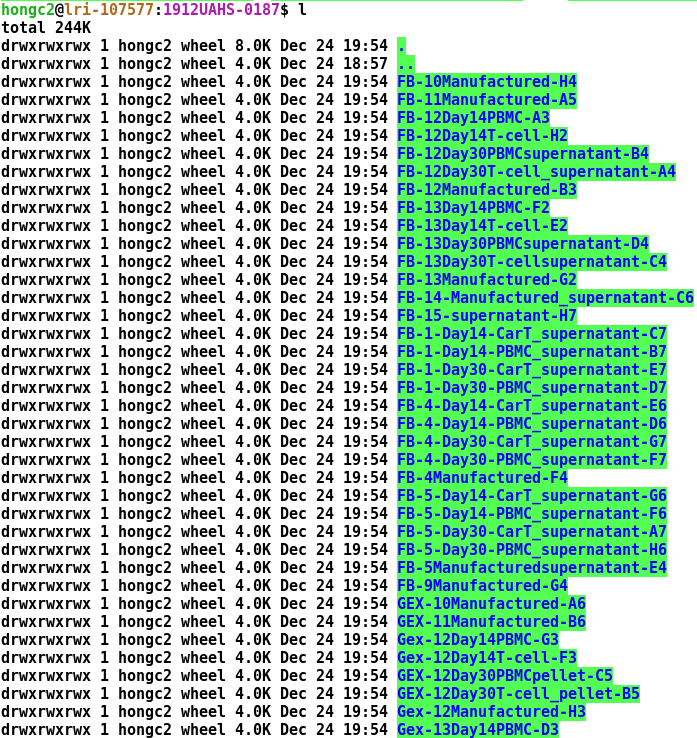

Fig2. Demultiplexed samples after mkfastq run

### 10x Genomics FASTQ files

- FASTQ file format: Three files form a group. I1 contains a sample barcode, R1 contains cell-barcode and UMI, and R2 is an actual cDNA read.

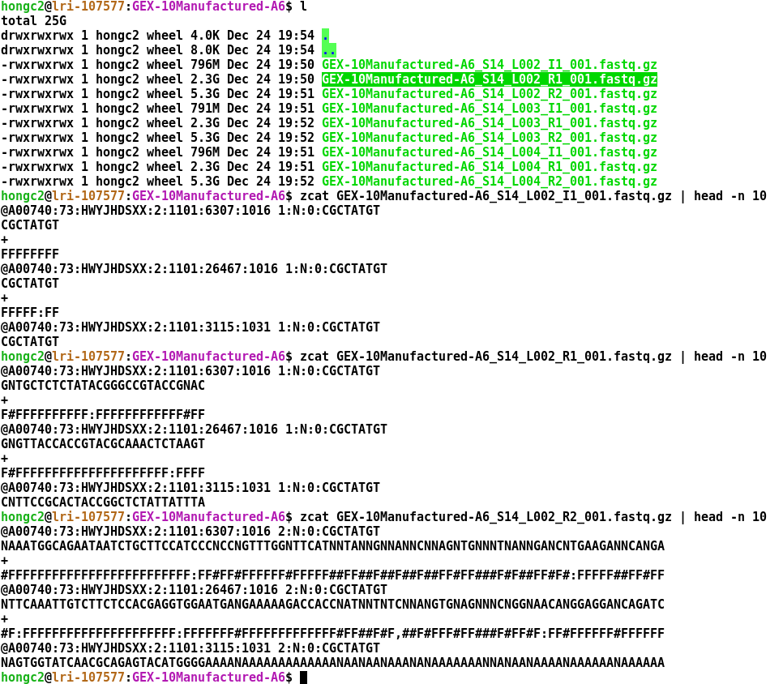

Fig3. 10x Genomics FASTQ file format

- *What is a sequence header?*
- *How many lines form one short read?*
- *What is “F:FFFFFFFF#…”?*
- Refer to [FASTQ file format](https://en.wikipedia.org/wiki/FASTQ_format)
- Refer to [Fastqc](https://www.bioinformatics.babraham.ac.uk/projects/fastqc/) to analyze FASTQ file quality and collect some useful statistics

### Things to know

- What is a FASTQ file?